# Guided Project: Scales and Facets

### A1 · Label it

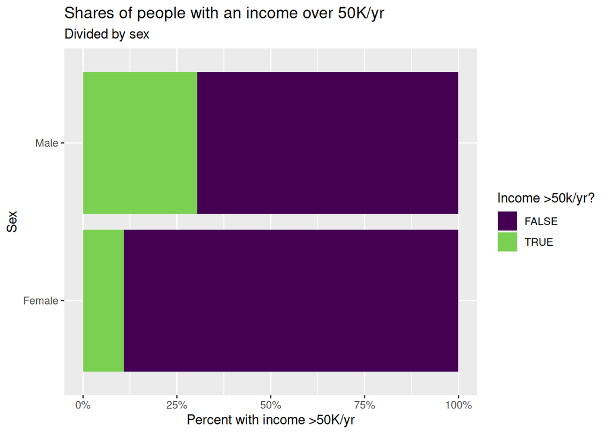

Figure 2: Share of each group with the outcome, labeled for a reader.

```r
a_data <- fairness %>%
  mutate(
    group = sex,
    has_outcome = (income == ">50K")
  )

a1_base <- ggplot(a_data, aes(y = group, fill = has_outcome)) +
  geom_bar(position = "fill") +
  labs(x = "Share of the group", y = NULL, fill = "Has the outcome")

a1 <- a1_base +
  labs(
    title = "Shares of people with an income over 50K/yr",
    subtitle = "Divided by sex",
    x = "Percent with income >50K/yr",
    y = "Sex",
    fill = "Income >50k/yr?"
  ) +
  scale_x_continuous(labels = scales::percent)

show_plot(a1)
```

The legend label is the most valuable change; the outcome was not originally listed, and therefore could not be interpreted without access to source code.

### A2 · Choose a scale

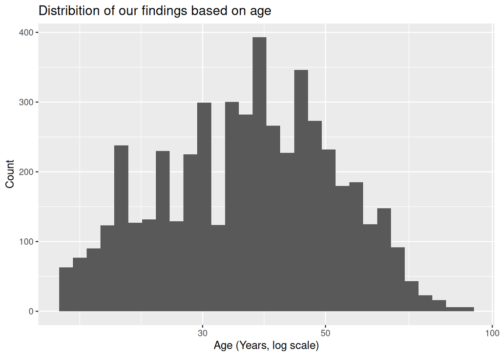

Figure 3: My scale choice.

```r
a2 <- NULL
# YOUR TURN: remove the # signs below, then replace each ___.
a2 <- fairness %>%
  filter(age > 0) %>%
  ggplot(aes(x = age)) +
  geom_histogram(bins = 30) +
  scale_x_log10(labels = scales::comma) +
  labs(title = "Distribition of our findings based on age", x = "Age (Years, log scale)", y = "Count")

# YOUR TURN: one sentence. Why this scale for this column?
a2_reason <- "Ages are skewed roughly, and we can see which ages have a central majority contribution."

show_plot(a2)
```

With the log10scale, readers are more clearly able to see the pattern of what ages are most common in the dataset; no values were removed, but now our graph has a far greater shape.

### A3 · Facet it: fixed or free

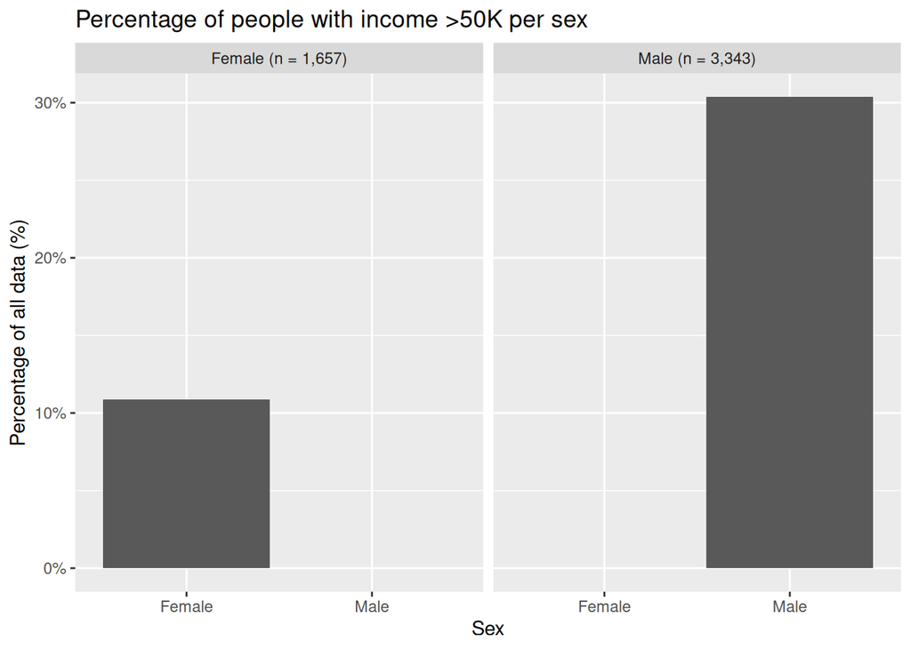

(a) Fixed

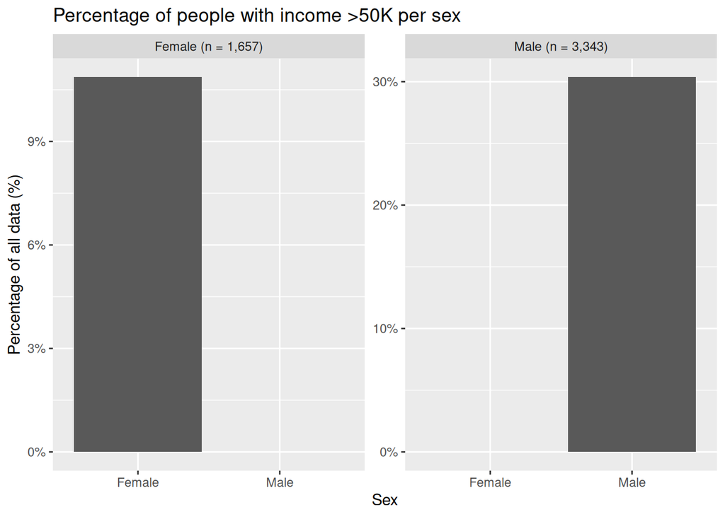

(b) Free

Figure 4: The same rates in panels: fixed and free y-axes.

```r
# YOUR TURN 1: replace "replace me" with your second column (no quotes).
a3_rates <- a_data %>%
  mutate(panel = sex) %>%
  drop_na(has_outcome) %>%
  add_count(panel, name = "panel_n") %>%
  mutate(panel = paste0(panel, " (n = ", scales::comma(panel_n), ")")) %>%
  group_by(panel, group) %>%
  summarize(n = n(), rate = mean(has_outcome), .groups = "drop")

a3_fixed <- NULL
a3_free <- NULL
# YOUR TURN 2: remove the # signs below, then replace each ___.
a3_fixed <- ggplot(a3_rates, aes(x = group, y = rate)) +
   geom_col() +
   facet_wrap(vars(panel)) +
   scale_y_continuous(labels = scales::percent) +
   labs(title = "Percentage of people with income >50K per sex", x = "Sex", y = "Percentage of all data (%)")
a3_free <- a3_fixed +
  facet_wrap(vars(panel), scales = "free_y")

# YOUR TURN 3: which one would you publish, "fixed" or "free_y"? Why?
a3_choice <- "fixed"
a3_reason <- "Fixed allows for proportions to be compared far more easily."

show_plot(a3_fixed)
show_plot(a3_free)
```

Table 1: Each group’s n and rate, by panel.

| panel | group | n | rate |
| --- | --- | --- | --- |
| Female (n = 1,657) | Female | 1657 | 0.109 |
| Male (n = 3,343) | Male | 3343 | 0.304 |

The Fixed axis is most accurate. While the free y-axis graph does show the correct markings per graph, it misleads the reader to believe the rate of males and the rate of females with the outcome of 50K or above is near-even. The females panel is roughly half the count of the males panel, at 1657 compared to 3343, and therefore even a minor change in interpretation could be incorrect.

### A4 · Compared to what?

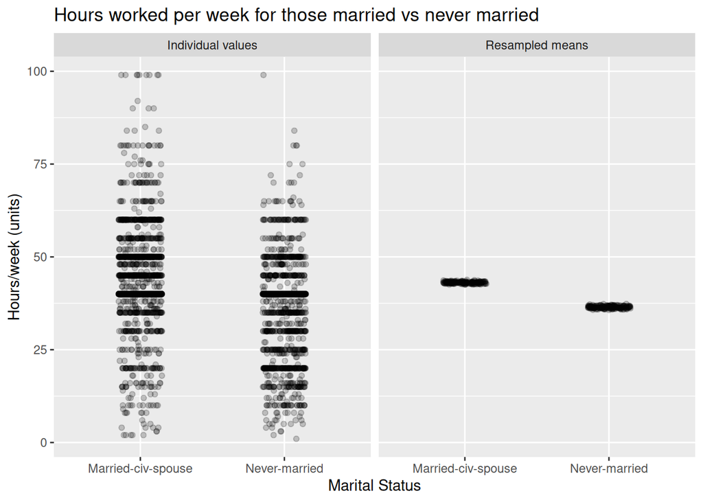

Figure 5: Two groups: individual values and resampled means, same axes.

```r
a4_clouds <- NULL
# YOUR TURN 1: remove the # signs below, then replace each ___: the column
# with your groups, two of its values, and your numeric column.
a4_clouds <- a_data %>%
  filter(marital_status %in% c("Never-married", "Married-civ-spouse")) %>%
  make_clouds(marital_status, hours_per_week)

a4 <- NULL
# YOUR TURN 2: remove the # signs below, then replace each ___.
a4 <- ggplot(a4_clouds, aes(x = group, y = value)) +
  geom_jitter(width = 0.15, height = 0, alpha = 0.2) +
  facet_wrap(~ kind) +
  labs(title = "Hours worked per week for those married vs never married", x = "Marital Status", y = "Hours/week (units)")

show_plot(a4)
```

Individual values overlap very frequently, and have similar spread; however, the means show that those who are traditionally married work, on average, more hours per week than those who have never been married.